# Coding Assignment #7

```r
library(ggplot2)
library(dplyr)
library(ggrepel)
```

### Q1

- Use the dataset “iris”
- Transparency of points (alpha) is 0.7
- The size of Sepal.Width is (1,4)

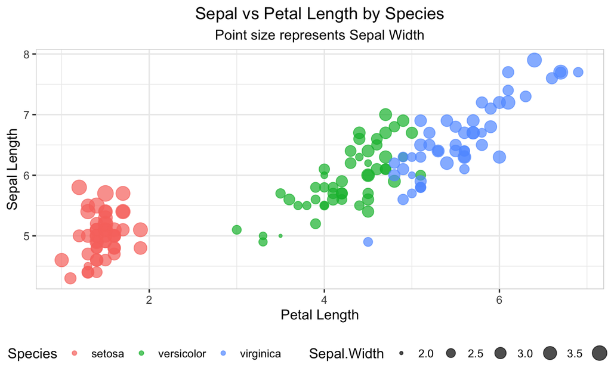

```r
ggplot(iris, mapping=aes(Petal.Length, Sepal.Length, color=Species, size=Sepal.Width))+
  geom_point(alpha=0.7)+
  labs(
    title= "Sepal vs Petal Length by Species",
    subtitle = "Point size represents Sepal Width",
    x = "Petal Length",
    y="Sepal Length"
  )+
  theme_bw(base_size = 12)+
  theme(
    plot.title = element_text(hjust=0.5),
    plot.subtitle = element_text(hjust=0.5),
    legend.position="bottom",
    panel.border = element_rect(color = "lightgray", fill = NA)
  )
```

```r
NA
NA
```

### Q2

- Use the dataset “mtcars”
- Point size is 2
- Use ggrepel() to add non-overlapping labels using car names (car name is the first column), the size of labels is 3. Please also note that everytime you run ggrepel, the position of labels will vary slightly, which is fine for this assignment.
- In ggrepel(), set the max.overlaps to be 50
- The two ends of the gradient color for legend are green and red
- The rectangular background is in blue with a transparency level = 0.3

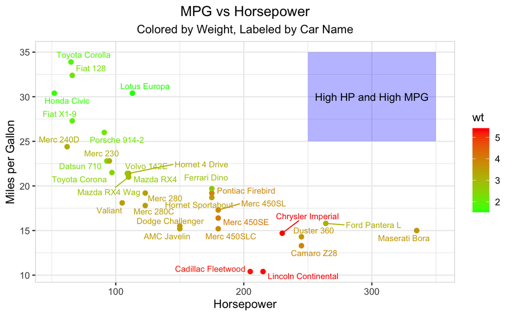

```r
mtcars$car_name <- rownames(mtcars)

ggplot(mtcars, mapping=aes(hp, mpg, color=wt))+
  geom_point(size=2)+
  annotate(
    "rect",
    xmin=250, xmax=350,
    ymin=25, ymax=35,
    alpha=0.3,
     fill="blue"
    )+
  annotate(
    "text",
    x= 300, y=30,
    label="High HP and High MPG"
  )+
  geom_text_repel(
    aes(label=car_name),
    size=3,
    max.overlaps = 50
  )+
  scale_color_gradient(low="green", high="red")+
  labs(
    title="MPG vs Horsepower",
    subtitle="Colored by Weight, Labeled by Car Name",
    x= "Horsepower",
    y="Miles per Gallon",
    legend = "Weight"
  )+
   theme_bw(base_size = 12)+
  theme(
    plot.title = element_text(hjust=0.5),
    plot.subtitle = element_text(hjust=0.5),
    panel.border = element_rect(color = "lightgray", fill = NA)
     )
```

```r
NA
NA
```

### Q3

- Use the dataset “diamonds”
- The number of bins in each facet is 50
- The color of bins is steelblue
- Pay attention to the range of X-axis labels

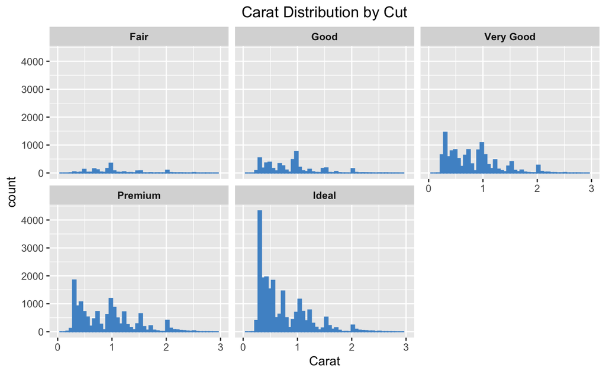

```r
ggplot(diamonds, mapping=aes(carat))+
  geom_histogram(fill="steelblue3", color="steelblue3", bins=50)+
  facet_wrap(~cut)+
  labs(
    title="Carat Distribution by Cut",
    x = "Carat"
  )+
  scale_x_continuous(
    limits = c(0,3),
    breaks = seq(0,3, by = 1)
  )+
  theme(
    strip.text = element_text(face = "bold"),
      plot.title = element_text(hjust=0.5)
  )
```

### Q4

- Use the dataset “iris”
- Pay attention to the range and interval of X-axis units
- The size range of Petal.Length legend is (1,4), breaks at 3 and 5.

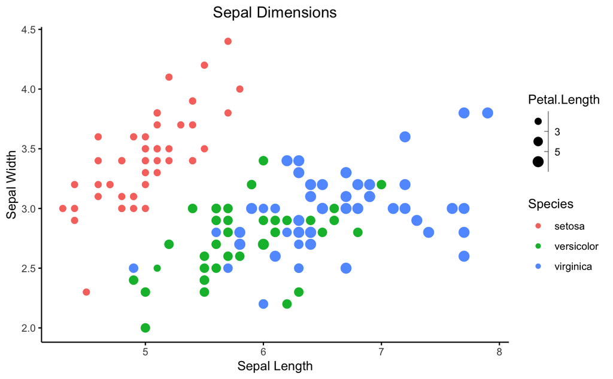

```r
ggplot(iris, mapping=aes(Sepal.Length, Sepal.Width, size=Petal.Length, color=Species))+
  geom_point()+
  scale_size_binned(
    range=c(1,4),
    breaks=c(3,5)
  )+
  labs(
    title = "Sepal Dimensions",
    x= "Sepal Length",
    y = "Sepal Width"
  )+
  theme(
    plot.title = element_text(hjust=0.5),
    panel.background = element_rect(fill = "white", color = NA),
  panel.grid.major = element_blank(),
  panel.grid.minor = element_blank(),
  axis.line = element_line(color = "black"),
  axis.ticks = element_line(color = "black")
    )
```

### Q5

- Use the dataset “ToothGrowth”
- The Y-axis represents the AVERAGE value of tooth length
- Pay attention to the label name in X-axis

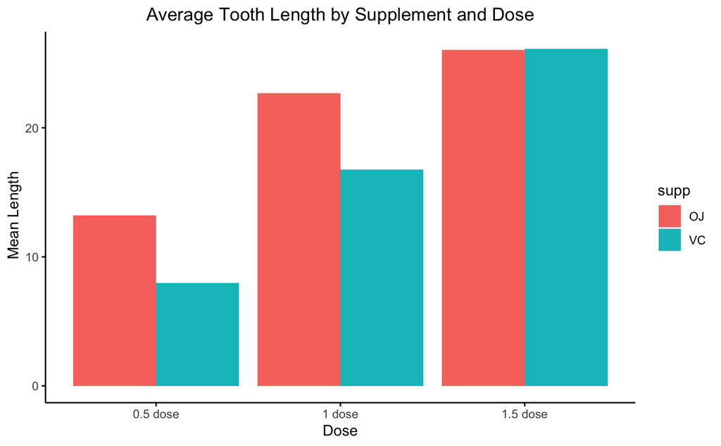

```r
ToothGrowth$dose <- as.factor(ToothGrowth$dose)

ggplot(ToothGrowth, mapping=aes(dose, len, fill=supp))+
  geom_bar(stat = "summary", fun = mean, position = "dodge")+
  scale_x_discrete(
    labels = c("0.5" = "0.5 dose", "1" = "1 dose", "2" = "1.5 dose")
      )+
  labs(
    title = "Average Tooth Length by Supplement and Dose",
    x = "Dose",
    y = " Mean Length"
  )+
  theme(
     plot.title = element_text(hjust=0.5),
    panel.background = element_rect(fill = "white", color = NA),
  panel.grid.major = element_blank(),
  panel.grid.minor = element_blank(),
  axis.line = element_line(color = "black"),
  axis.ticks = element_line(color = "black")
  )
```

```r
NA
NA
```

### Q6:

- Use the dataset “ChickWeight”
- The Y-axis represents the AVERAGE value of chick weight
- The line is in blue, and dots are in black.

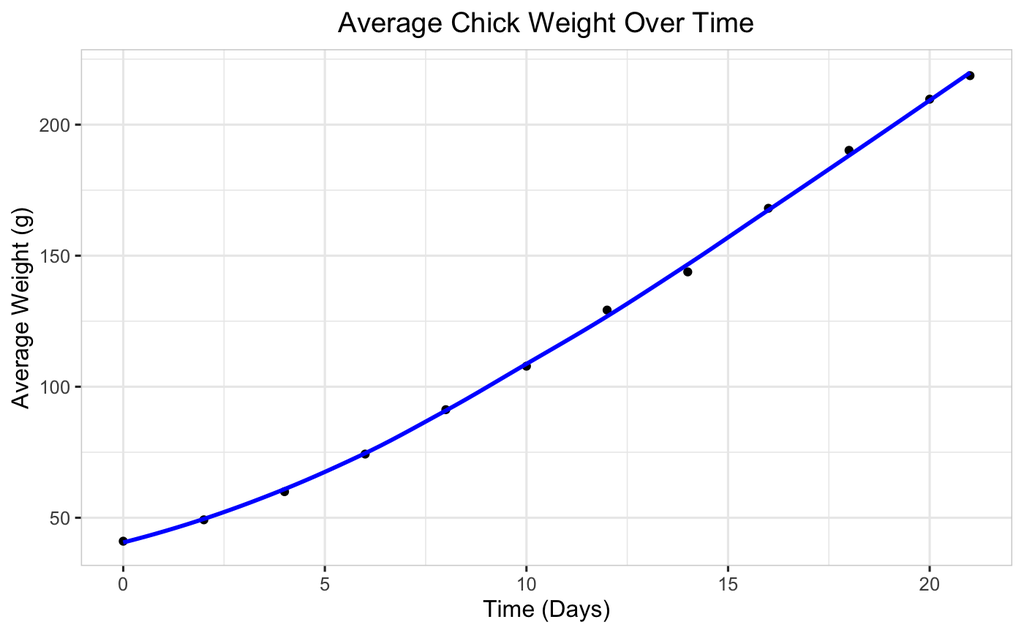

```r
avg_data <- ChickWeight %>%
  group_by(Time) %>%
  summarise(avg_weight = mean(weight), .groups = 'drop')

ggplot(avg_data, aes(x = Time, y = avg_weight)) +
  geom_point(color = "black") +
  geom_smooth(method = "loess", color = "blue", se = FALSE)+
  labs(
    title="Average Chick Weight Over Time",
    x= "Time (Days)",
    y= "Average Weight (g)"
  )+
  theme_bw(base_size = 12)+
  theme(
     plot.title = element_text(hjust=0.5),
      panel.border = element_rect(color = "lightgray", fill = NA)
    )
```

### Q7

-Use the dataset “airquality” -The color gradient goes from “lightpink” to “lightblue” -The line is in blue

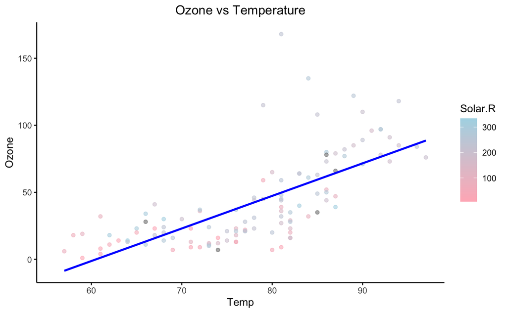

```r
ggplot(airquality, mapping=aes(Temp, Ozone, color=Solar.R))+
  geom_point(alpha=0.6)+
  geom_smooth(method = "lm", se = FALSE, color = "blue")+
  scale_color_gradient(low="lightpink", high="lightblue")+
  labs(
    title = "Ozone vs Temperature",
    x = "Temp",
    y = "Ozone",
    legend = "Solar Radiation"
  )+
   theme(
     plot.title = element_text(hjust=0.5),
    panel.background = element_rect(fill = "white", color = NA),
  panel.grid.major = element_blank(),
  panel.grid.minor = element_blank(),
  axis.line = element_line(color = "black"),
  axis.ticks = element_line(color = "black")
  )
```

### Q8:

- Use the dataset “HairEyeColor”
- The Y-axis represents Frequencies(count)
- Use palette “Set3” in brewer to color(fill) the bars, consider using scale_fill_brewer()

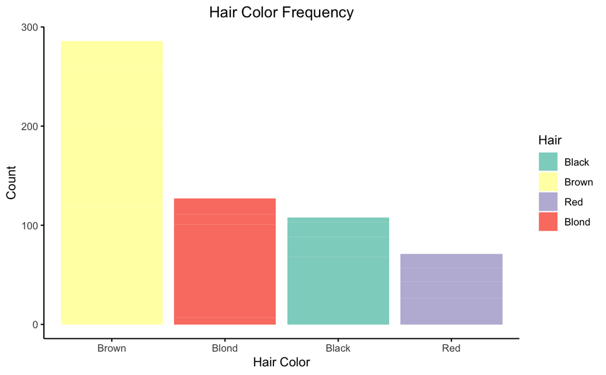

```r
df <- as.data.frame(HairEyeColor)

# Summarize: total count by hair and eye color
hair_eye <- df %>%
  group_by(Hair, Eye) %>%
  summarise(total = sum(Freq), .groups = "drop")

# Plot
ggplot(hair_eye, aes(x = reorder(Hair, -total), y = total, fill = Hair)) +
  geom_bar(stat = "identity") +
  scale_fill_brewer(palette = "Set3")+
  labs(
    title = "Hair Color Frequency",
    x = "Hair Color",
    y= "Count"
  )+
  theme(
     plot.title = element_text(hjust=0.5),
    panel.background = element_rect(fill = "white", color = NA),
  panel.grid.major = element_blank(),
  panel.grid.minor = element_blank(),
  axis.line = element_line(color = "black"),
  axis.ticks = element_line(color = "black")
  )
```

```r
NA
```

### Q9

- Use the dataset “airquality”
- The Y-axis represents the MEAN temperature of each month

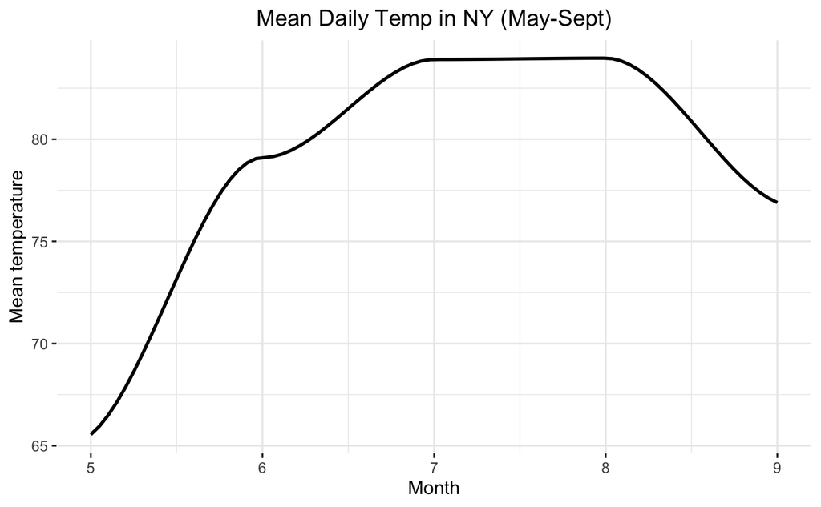

```r
mean_temp_month <- airquality %>%
  filter(!is.na(Temp)) %>%
  group_by(Month) %>%
  summarise(mean_temp = mean(Temp), .groups="drop")

ggplot(mean_temp_month, aes(x = Month, y = mean_temp)) +
  geom_smooth(method = "loess", se = FALSE, color="black")+
  labs(
    title="Mean Daily Temp in NY (May-Sept)",
    x = "Month",
    y = "Mean temperature"
  )+
   theme_bw(base_size = 12)+
  theme(
  plot.title = element_text(hjust=0.5),
   panel.border = element_rect(color = "white", fill = NA)

  )
```

```r
NA
```

### Q10

- Use the dataset “mtcars”
- The Y-axis represents the AVERAGE hp
- Consider using factor(gear) for X-axis
- Bars are in steelblue

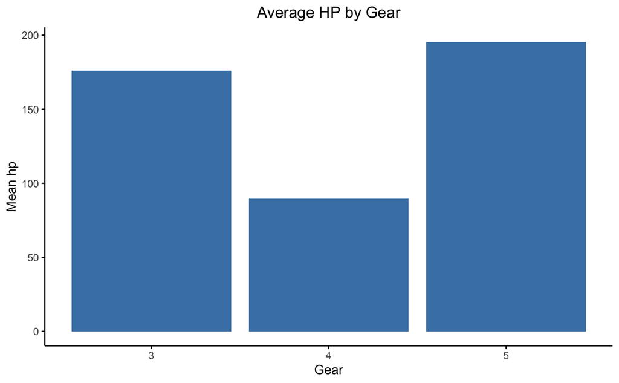

```r
avg_hp_gear <- mtcars %>%
  group_by(gear) %>%
  summarise(avg_hp = mean(hp), .groups = "drop")

ggplot(avg_hp_gear, aes(x = factor(gear), y = avg_hp, fill = "steelblue")) +
  geom_bar(stat = "identity", show.legend = FALSE) +
  scale_fill_manual(values = "steelblue")+
  labs(
    title = "Average HP by Gear",
    x= "Gear",
    y = "Mean hp"
  )+
   theme(
     plot.title = element_text(hjust=0.5),
    panel.background = element_rect(fill = "white", color = NA),
  panel.grid.major = element_blank(),
  panel.grid.minor = element_blank(),
  axis.line = element_line(color = "black"),
  axis.ticks = element_line(color = "black")
  )
```

```r
NA
NA
NA
```